# DATA624_Homework5

## 6) Forecast the Chinese GDP from the global_economy data set using an ETS model. Experiment with the various options in the ETS() function to see how much the forecasts change with damped trend, or with a Box-Cox transformation. Try to develop an intuition of what each is doing to the forecasts.

#### [Hint: use a relatively large value of h when forecasting, so you can clearly see the differences between the various options when plotting the forecasts.]

For this exercise, I generated three different models. One with No trend of Seasonal accommodations, so it was Simple Exponential Smoothing, the second with an additive trend accommodation (Holt’s Linear Model), and then a dampened trend model. Of all of them I think the dampened trend model seems to look the most promising, as the Holt Linear model is, as the textbook states “display[s] a constant trend… indefinitely into the future”. Simple Expoential Snoothing does not take into account the trends in the data, and the dampened projection dampens newer data’s consistent influence on the data so as to control for overestimating its influence.

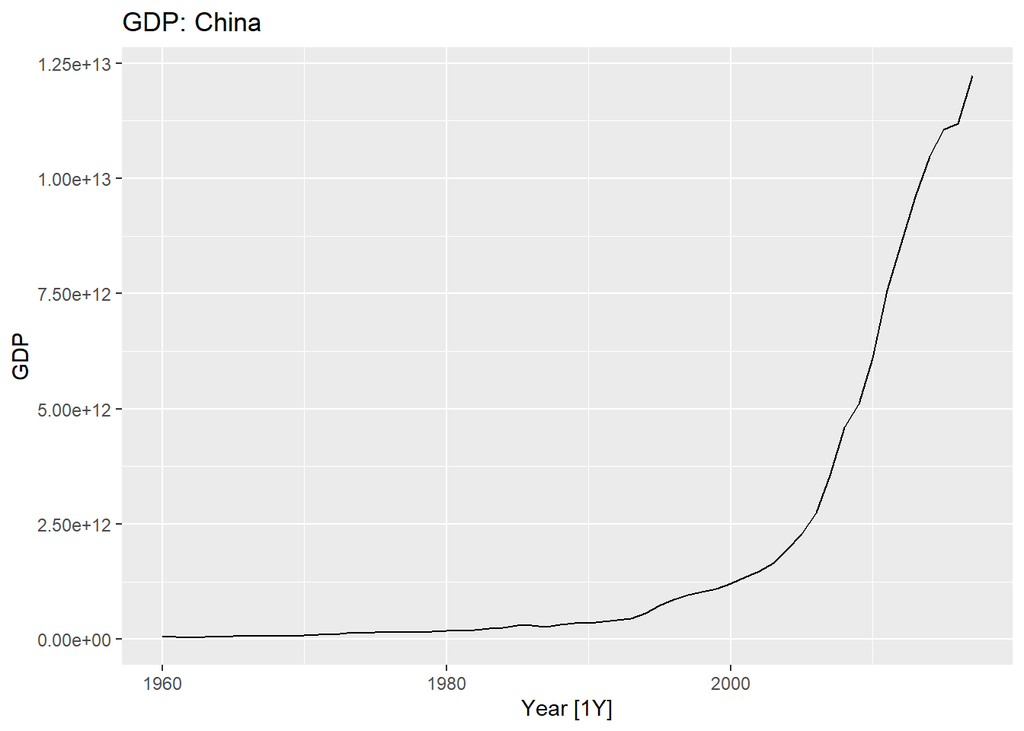

```r
china_economy <- global_economy |>
  filter(Country == "China")
# Initial Plot of the data
china_economy |>
  autoplot(GDP) +
  labs(y = "GDP", title = "GDP: China")
```

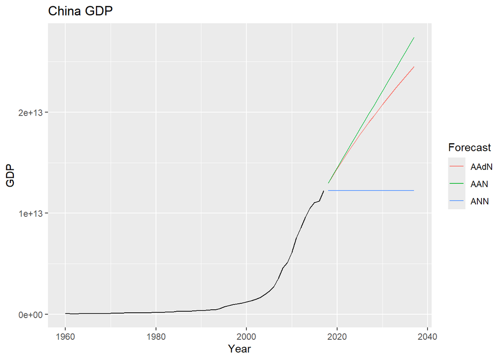

```r
# Starting to Model
china_economy |>
  model(
    ## NO Trend Accommodation
    `ANN` = ETS(GDP ~ error("A") +trend("N") + season("N")),
    ## With Additive Trend Accommodation
    `AAN` = ETS(GDP ~ error("A") + trend("A") + season("N")),
    # Dampered Additive Trend Accomodation
    `AAdN` = ETS(GDP ~ error("A") + trend("Ad") + season("N"))
  ) |>
  forecast(h = 20) |>
  autoplot(china_economy, level = NULL) +
  labs(title = "China GDP",
       y = "GDP") +
  guides(colour = guide_legend(title = "Forecast"))
```

## 7) Find an ETS model for the Gas data from aus_production and forecast the next few years. Why is multiplicative seasonality necessary here? Experiment with making the trend damped. Does it improve the forecasts?

Firstly, multiplicative seasonality is necessary here as there is a strong level of seasonal variation from quarter to quarter. This needs to be accomodated for. Additionally, there are changes from seasons to season so we want to avoid absolute values for this measure, so multiplicative seasonality is needed.

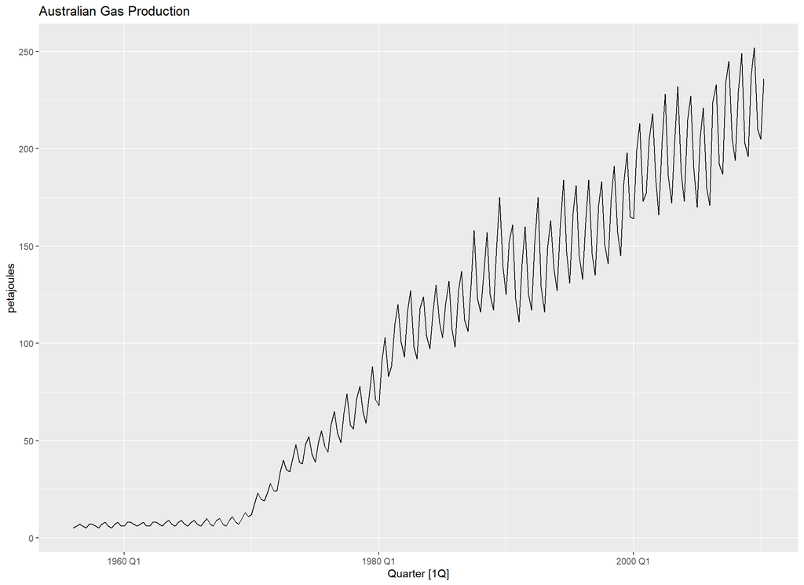

```r
#?aus_production
aus_gas<- aus_production |> select(Quarter, Gas)
# Initial Plot of the data
aus_gas |>
  autoplot(Gas) +
  labs(y = "petajoules", title = "Australian Gas Production")
```

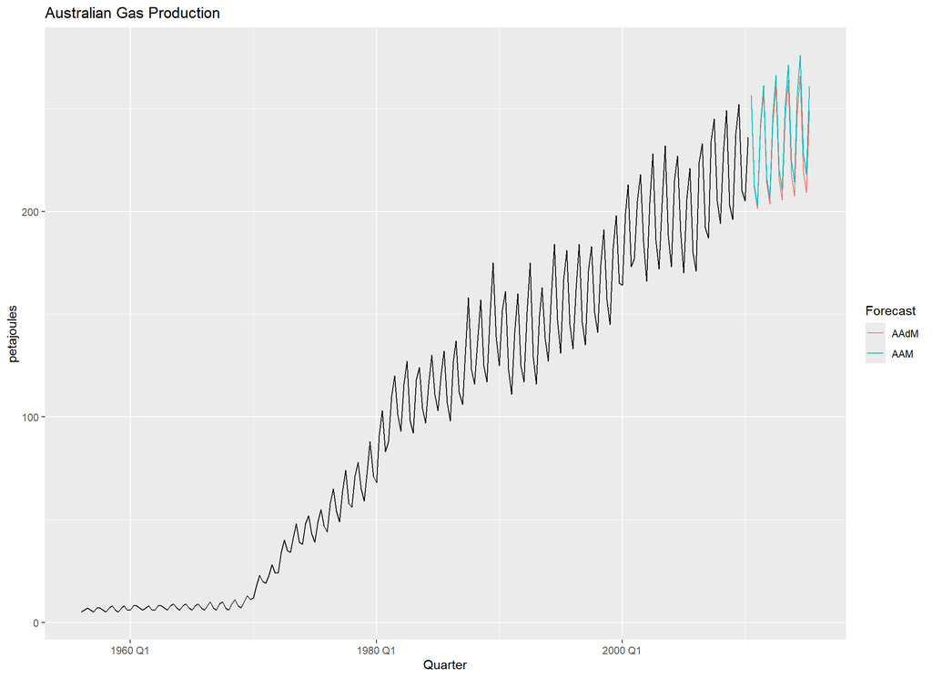

```r
## Firstly there is a trend and there is seasonality here b/c of question we will do an AAN model, AAdM and an AAM

# Starting to Model
aus_gas |>
  model(
    ## With Additive Trend Accommodation
    `AAM` = ETS(Gas ~ error("A") + trend("A") + season("M")),
    # Dampered Additive Trend Accommodation
    `AAdM` = ETS(Gas ~ error("A") + trend("Ad") + season("M"))
  ) |>
  forecast(h = 20) |> # Four years
  autoplot(aus_gas, level = NULL) +
  labs(title = "Australian Gas Production",
       y = "petajoules") +
  guides(colour = guide_legend(title = "Forecast"))
```

```r
aam <- aus_gas |> model(ETS(Gas ~ error("A") + trend("A") + season("M")))
print(tidy(aam))
```

```
## # A tibble: 9 × 3
##   .model                                                   term  estimate
##   <chr>                                                    <chr>    <dbl>
## 1 "ETS(Gas ~ error(\"A\") + trend(\"A\") + season(\"M\"))" alpha  0.613
## 2 "ETS(Gas ~ error(\"A\") + trend(\"A\") + season(\"M\"))" beta   0.00786
## 3 "ETS(Gas ~ error(\"A\") + trend(\"A\") + season(\"M\"))" gamma  0.224
## 4 "ETS(Gas ~ error(\"A\") + trend(\"A\") + season(\"M\"))" l[0]   3.62
## 5 "ETS(Gas ~ error(\"A\") + trend(\"A\") + season(\"M\"))" b[0]   0.610
## 6 "ETS(Gas ~ error(\"A\") + trend(\"A\") + season(\"M\"))" s[0]   0.980
## 7 "ETS(Gas ~ error(\"A\") + trend(\"A\") + season(\"M\"))" s[-1]  1.15
## 8 "ETS(Gas ~ error(\"A\") + trend(\"A\") + season(\"M\"))" s[-2]  1.08
## 9 "ETS(Gas ~ error(\"A\") + trend(\"A\") + season(\"M\"))" s[-3]  0.797
```

```r
print(accuracy(aam))
```

```
## # A tibble: 1 × 10
##   .model                 .type    ME  RMSE   MAE    MPE  MAPE  MASE RMSSE   ACF1
##   <chr>                  <chr> <dbl> <dbl> <dbl>  <dbl> <dbl> <dbl> <dbl>  <dbl>
## 1 "ETS(Gas ~ error(\"A\… Trai… 0.218  4.19  2.84 -0.920  5.03 0.510 0.553 0.0405
```

```r
aadm <- aus_gas |> model(ETS(Gas ~ error("A") + trend("Ad") + season("M")))
print(tidy(aadm))
```

```
## # A tibble: 10 × 3
##    .model                                                    term  estimate
##    <chr>                                                     <chr>    <dbl>
##  1 "ETS(Gas ~ error(\"A\") + trend(\"Ad\") + season(\"M\"))" alpha   0.610
##  2 "ETS(Gas ~ error(\"A\") + trend(\"Ad\") + season(\"M\"))" beta    0.0249
##  3 "ETS(Gas ~ error(\"A\") + trend(\"Ad\") + season(\"M\"))" gamma   0.223
##  4 "ETS(Gas ~ error(\"A\") + trend(\"Ad\") + season(\"M\"))" phi     0.980
##  5 "ETS(Gas ~ error(\"A\") + trend(\"Ad\") + season(\"M\"))" l[0]    5.64
##  6 "ETS(Gas ~ error(\"A\") + trend(\"Ad\") + season(\"M\"))" b[0]   -0.0618
##  7 "ETS(Gas ~ error(\"A\") + trend(\"Ad\") + season(\"M\"))" s[0]    0.925
##  8 "ETS(Gas ~ error(\"A\") + trend(\"Ad\") + season(\"M\"))" s[-1]   1.06
##  9 "ETS(Gas ~ error(\"A\") + trend(\"Ad\") + season(\"M\"))" s[-2]   1.12
## 10 "ETS(Gas ~ error(\"A\") + trend(\"Ad\") + season(\"M\"))" s[-3]   0.890
```

```r
print(accuracy(aadm))
```

```
## # A tibble: 1 × 10
##   .model                  .type    ME  RMSE   MAE   MPE  MAPE  MASE RMSSE   ACF1
##   <chr>                   <chr> <dbl> <dbl> <dbl> <dbl> <dbl> <dbl> <dbl>  <dbl>
## 1 "ETS(Gas ~ error(\"A\"… Trai… 0.548  4.22  2.81  1.32  4.11 0.505 0.556 0.0265
```

## 8) Recall your retail time series data (from Exercise 7 in Section 2.10).

```r
set.seed(12345678)
myseries <- aus_retail |>
  filter(`Series ID` == sample(aus_retail$`Series ID`,1))
```

#### a) Why is multiplicative seasonality necessary for this series?

Multiplicative seasonality is necessary for this series because the seasonal variations are changing over time, therefore we want a relative measurment for predicting values, not an absolution one stemming from addition.

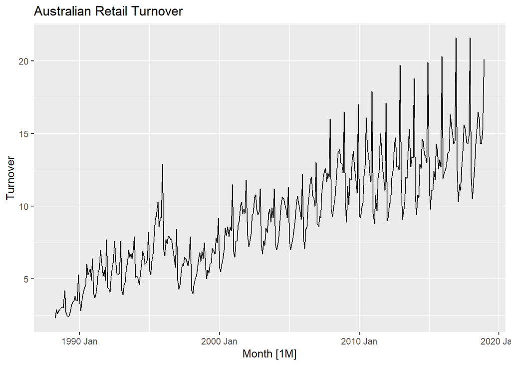

```r
## Plotting the time series
myseries |>
 autoplot(Turnover) +
  labs(y = "Turnover", title = "Australian Retail Turnover")
```

#### b) Apply Holt-Winters’ multiplicative method to the data. Experiment with making the trend damped.

```r
aam <- myseries |> model(ETS(Turnover ~ error("A") + trend("A") + season("M")))
print(tidy(aam))
```

```
## # A tibble: 17 × 5
##    State              Industry                             .model term  estimate
##    <chr>              <chr>                                <chr>  <chr>    <dbl>
##  1 Northern Territory Clothing, footwear and personal acc… "ETS(… alpha 0.550
##  2 Northern Territory Clothing, footwear and personal acc… "ETS(… beta  0.000100
##  3 Northern Territory Clothing, footwear and personal acc… "ETS(… gamma 0.202
##  4 Northern Territory Clothing, footwear and personal acc… "ETS(… l[0]  2.35
##  5 Northern Territory Clothing, footwear and personal acc… "ETS(… b[0]  0.0334
##  6 Northern Territory Clothing, footwear and personal acc… "ETS(… s[0]  0.813
##  7 Northern Territory Clothing, footwear and personal acc… "ETS(… s[-1] 0.798
##  8 Northern Territory Clothing, footwear and personal acc… "ETS(… s[-2] 0.775
##  9 Northern Territory Clothing, footwear and personal acc… "ETS(… s[-3] 1.32
## 10 Northern Territory Clothing, footwear and personal acc… "ETS(… s[-4] 0.992
## 11 Northern Territory Clothing, footwear and personal acc… "ETS(… s[-5] 1.06
## 12 Northern Territory Clothing, footwear and personal acc… "ETS(… s[-6] 1.00
## 13 Northern Territory Clothing, footwear and personal acc… "ETS(… s[-7] 1.14
## 14 Northern Territory Clothing, footwear and personal acc… "ETS(… s[-8] 1.21
## 15 Northern Territory Clothing, footwear and personal acc… "ETS(… s[-9] 1.02
## 16 Northern Territory Clothing, footwear and personal acc… "ETS(… s[-1… 0.998
## 17 Northern Territory Clothing, footwear and personal acc… "ETS(… s[-1… 0.871
```

```r
print(accuracy(aam))
```

```
## # A tibble: 1 × 12
##   State      Industry .model .type       ME  RMSE   MAE    MPE  MAPE  MASE RMSSE
##   <chr>      <chr>    <chr>  <chr>    <dbl> <dbl> <dbl>  <dbl> <dbl> <dbl> <dbl>
## 1 Northern … Clothin… "ETS(… Trai… -0.00119 0.600 0.443 -0.265  5.21 0.506 0.517
## # ℹ 1 more variable: ACF1 <dbl>
```

```r
aadm <- myseries |> model(ETS(Turnover ~ error("A") + trend("Ad") + season("M")))
print(tidy(aadm))
```

```
## # A tibble: 18 × 5
##    State              Industry                             .model term  estimate
##    <chr>              <chr>                                <chr>  <chr>    <dbl>
##  1 Northern Territory Clothing, footwear and personal acc… "ETS(… alpha  5.56e-1
##  2 Northern Territory Clothing, footwear and personal acc… "ETS(… beta   1.07e-4
##  3 Northern Territory Clothing, footwear and personal acc… "ETS(… gamma  2.07e-1
##  4 Northern Territory Clothing, footwear and personal acc… "ETS(… phi    8.44e-1
##  5 Northern Territory Clothing, footwear and personal acc… "ETS(… l[0]   2.64e+0
##  6 Northern Territory Clothing, footwear and personal acc… "ETS(… b[0]  -5.16e-2
##  7 Northern Territory Clothing, footwear and personal acc… "ETS(… s[0]   8.03e-1
##  8 Northern Territory Clothing, footwear and personal acc… "ETS(… s[-1]  8.06e-1
##  9 Northern Territory Clothing, footwear and personal acc… "ETS(… s[-2]  8.20e-1
## 10 Northern Territory Clothing, footwear and personal acc… "ETS(… s[-3]  1.31e+0
## 11 Northern Territory Clothing, footwear and personal acc… "ETS(… s[-4]  9.72e-1
## 12 Northern Territory Clothing, footwear and personal acc… "ETS(… s[-5]  1.06e+0
## 13 Northern Territory Clothing, footwear and personal acc… "ETS(… s[-6]  1.03e+0
## 14 Northern Territory Clothing, footwear and personal acc… "ETS(… s[-7]  1.10e+0
## 15 Northern Territory Clothing, footwear and personal acc… "ETS(… s[-8]  1.22e+0
## 16 Northern Territory Clothing, footwear and personal acc… "ETS(… s[-9]  1.05e+0
## 17 Northern Territory Clothing, footwear and personal acc… "ETS(… s[-1…  9.99e-1
## 18 Northern Territory Clothing, footwear and personal acc… "ETS(… s[-1…  8.41e-1
```

```r
print(accuracy(aadm))
```

```
## # A tibble: 1 × 12
##   State Industry .model .type     ME  RMSE   MAE   MPE  MAPE  MASE RMSSE    ACF1
##   <chr> <chr>    <chr>  <chr>  <dbl> <dbl> <dbl> <dbl> <dbl> <dbl> <dbl>   <dbl>
## 1 Nort… Clothin… "ETS(… Trai… 0.0582 0.602 0.449 0.499  5.23 0.512 0.520 -0.0490
```

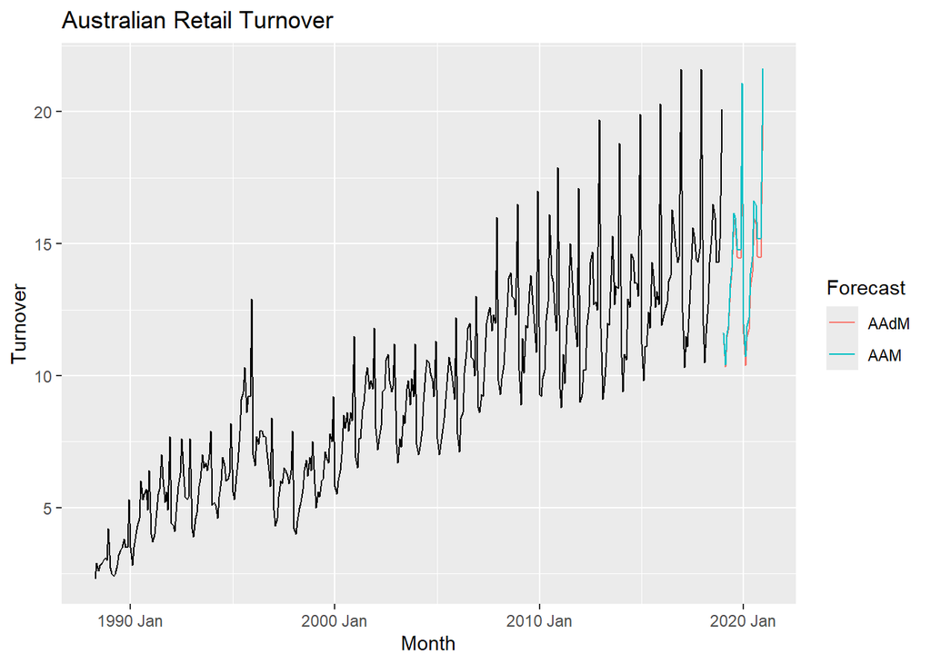

```r
# Starting to Model
myseries |>
  model(
    'AAM' = ETS(Turnover ~ error("A") + trend("A") + season("M")),
    'AAdM' = ETS(Turnover ~ error("A") + trend("Ad") + season("M"))
    ) |>
  forecast(h = 24) |> # 2 years
  autoplot(myseries, level = NULL) +
  labs(title = "Australian Retail Turnover",
       y = "Turnover") +
  guides(colour = guide_legend(title = "Forecast"))
```

#### c) Compare the RMSE of the one-step forecasts from the two methods. Which do you prefer?

While based on the plot and visualization of the data forecast i would say the damped trend looks to be more accurate, the RMSE for these models shows that the lower error value is yielded from the Additive non damped trend accommodation with a RMSE of ~0.599, while the damped model had a RMSE of 0.602. Both values are extremely close.

```r
aam <- myseries |> model(ETS(Turnover ~ error("A") + trend("A") + season("M")))
print(tidy(aam))
```

```
## # A tibble: 17 × 5
##    State              Industry                             .model term  estimate
##    <chr>              <chr>                                <chr>  <chr>    <dbl>
##  1 Northern Territory Clothing, footwear and personal acc… "ETS(… alpha 0.550
##  2 Northern Territory Clothing, footwear and personal acc… "ETS(… beta  0.000100
##  3 Northern Territory Clothing, footwear and personal acc… "ETS(… gamma 0.202
##  4 Northern Territory Clothing, footwear and personal acc… "ETS(… l[0]  2.35
##  5 Northern Territory Clothing, footwear and personal acc… "ETS(… b[0]  0.0334
##  6 Northern Territory Clothing, footwear and personal acc… "ETS(… s[0]  0.813
##  7 Northern Territory Clothing, footwear and personal acc… "ETS(… s[-1] 0.798
##  8 Northern Territory Clothing, footwear and personal acc… "ETS(… s[-2] 0.775
##  9 Northern Territory Clothing, footwear and personal acc… "ETS(… s[-3] 1.32
## 10 Northern Territory Clothing, footwear and personal acc… "ETS(… s[-4] 0.992
## 11 Northern Territory Clothing, footwear and personal acc… "ETS(… s[-5] 1.06
## 12 Northern Territory Clothing, footwear and personal acc… "ETS(… s[-6] 1.00
## 13 Northern Territory Clothing, footwear and personal acc… "ETS(… s[-7] 1.14
## 14 Northern Territory Clothing, footwear and personal acc… "ETS(… s[-8] 1.21
## 15 Northern Territory Clothing, footwear and personal acc… "ETS(… s[-9] 1.02
## 16 Northern Territory Clothing, footwear and personal acc… "ETS(… s[-1… 0.998
## 17 Northern Territory Clothing, footwear and personal acc… "ETS(… s[-1… 0.871
```

```r
aam_forecast <- aam |>  forecast(h = 12)
print(aam_forecast)
```

```
## # A fable: 12 x 6 [1M]
## # Key:     State, Industry, .model [1]
##    State              Industry                .model    Month     Turnover .mean
##    <chr>              <chr>                   <chr>     <mth>       <dist> <dbl>
##  1 Northern Territory Clothing, footwear and… "ETS(… 2019 Jan sample[5000]  11.6
##  2 Northern Territory Clothing, footwear and… "ETS(… 2019 Feb sample[5000]  10.4
##  3 Northern Territory Clothing, footwear and… "ETS(… 2019 Mar sample[5000]  11.6
##  4 Northern Territory Clothing, footwear and… "ETS(… 2019 Apr sample[5000]  11.9
##  5 Northern Territory Clothing, footwear and… "ETS(… 2019 May sample[5000]  13.5
##  6 Northern Territory Clothing, footwear and… "ETS(… 2019 Jun sample[5000]  14.1
##  7 Northern Territory Clothing, footwear and… "ETS(… 2019 Jul sample[5000]  16.2
##  8 Northern Territory Clothing, footwear and… "ETS(… 2019 Aug sample[5000]  16.0
##  9 Northern Territory Clothing, footwear and… "ETS(… 2019 Sep sample[5000]  14.8
## 10 Northern Territory Clothing, footwear and… "ETS(… 2019 Oct sample[5000]  14.8
## 11 Northern Territory Clothing, footwear and… "ETS(… 2019 Nov sample[5000]  14.8
## 12 Northern Territory Clothing, footwear and… "ETS(… 2019 Dec sample[5000]  21.1
```

```r
print(accuracy(aam))#RMSE 0.5995194
```

```
## # A tibble: 1 × 12
##   State      Industry .model .type       ME  RMSE   MAE    MPE  MAPE  MASE RMSSE
##   <chr>      <chr>    <chr>  <chr>    <dbl> <dbl> <dbl>  <dbl> <dbl> <dbl> <dbl>
## 1 Northern … Clothin… "ETS(… Trai… -0.00119 0.600 0.443 -0.265  5.21 0.506 0.517
## # ℹ 1 more variable: ACF1 <dbl>
```

```r
aadm <- myseries |> model(ETS(Turnover ~ error("A") + trend("Ad") + season("M")))
print(tidy(aadm))
```

```
## # A tibble: 18 × 5
##    State              Industry                             .model term  estimate
##    <chr>              <chr>                                <chr>  <chr>    <dbl>
##  1 Northern Territory Clothing, footwear and personal acc… "ETS(… alpha  5.56e-1
##  2 Northern Territory Clothing, footwear and personal acc… "ETS(… beta   1.07e-4
##  3 Northern Territory Clothing, footwear and personal acc… "ETS(… gamma  2.07e-1
##  4 Northern Territory Clothing, footwear and personal acc… "ETS(… phi    8.44e-1
##  5 Northern Territory Clothing, footwear and personal acc… "ETS(… l[0]   2.64e+0
##  6 Northern Territory Clothing, footwear and personal acc… "ETS(… b[0]  -5.16e-2
##  7 Northern Territory Clothing, footwear and personal acc… "ETS(… s[0]   8.03e-1
##  8 Northern Territory Clothing, footwear and personal acc… "ETS(… s[-1]  8.06e-1
##  9 Northern Territory Clothing, footwear and personal acc… "ETS(… s[-2]  8.20e-1
## 10 Northern Territory Clothing, footwear and personal acc… "ETS(… s[-3]  1.31e+0
## 11 Northern Territory Clothing, footwear and personal acc… "ETS(… s[-4]  9.72e-1
## 12 Northern Territory Clothing, footwear and personal acc… "ETS(… s[-5]  1.06e+0
## 13 Northern Territory Clothing, footwear and personal acc… "ETS(… s[-6]  1.03e+0
## 14 Northern Territory Clothing, footwear and personal acc… "ETS(… s[-7]  1.10e+0
## 15 Northern Territory Clothing, footwear and personal acc… "ETS(… s[-8]  1.22e+0
## 16 Northern Territory Clothing, footwear and personal acc… "ETS(… s[-9]  1.05e+0
## 17 Northern Territory Clothing, footwear and personal acc… "ETS(… s[-1…  9.99e-1
## 18 Northern Territory Clothing, footwear and personal acc… "ETS(… s[-1…  8.41e-1
```

```r
aadm_forecast <-aadm |>  forecast(h = 12)
print(aadm_forecast)
```

```
## # A fable: 12 x 6 [1M]
## # Key:     State, Industry, .model [1]
##    State              Industry                .model    Month     Turnover .mean
##    <chr>              <chr>                   <chr>     <mth>       <dist> <dbl>
##  1 Northern Territory Clothing, footwear and… "ETS(… 2019 Jan sample[5000]  11.5
##  2 Northern Territory Clothing, footwear and… "ETS(… 2019 Feb sample[5000]  10.3
##  3 Northern Territory Clothing, footwear and… "ETS(… 2019 Mar sample[5000]  11.4
##  4 Northern Territory Clothing, footwear and… "ETS(… 2019 Apr sample[5000]  11.7
##  5 Northern Territory Clothing, footwear and… "ETS(… 2019 May sample[5000]  13.3
##  6 Northern Territory Clothing, footwear and… "ETS(… 2019 Jun sample[5000]  13.9
##  7 Northern Territory Clothing, footwear and… "ETS(… 2019 Jul sample[5000]  15.9
##  8 Northern Territory Clothing, footwear and… "ETS(… 2019 Aug sample[5000]  15.7
##  9 Northern Territory Clothing, footwear and… "ETS(… 2019 Sep sample[5000]  14.4
## 10 Northern Territory Clothing, footwear and… "ETS(… 2019 Oct sample[5000]  14.4
## 11 Northern Territory Clothing, footwear and… "ETS(… 2019 Nov sample[5000]  14.4
## 12 Northern Territory Clothing, footwear and… "ETS(… 2019 Dec sample[5000]  20.4
```

```r
print(accuracy(aadm)) #RSME 0.6024724
```

```
## # A tibble: 1 × 12
##   State Industry .model .type     ME  RMSE   MAE   MPE  MAPE  MASE RMSSE    ACF1
##   <chr> <chr>    <chr>  <chr>  <dbl> <dbl> <dbl> <dbl> <dbl> <dbl> <dbl>   <dbl>
## 1 Nort… Clothin… "ETS(… Trai… 0.0582 0.602 0.449 0.499  5.23 0.512 0.520 -0.0490
```

#### d) Check that the residuals from the best method look like white noise.

This plot of residuals looks like mostly white noise, with some variation exceptions towards the more recent / right portion of the chart. That being said, the variations dont have a pattern behind them, so can also be considered white noise.

```
## Plot variable not specified, automatically selected `.vars = .resid`
```

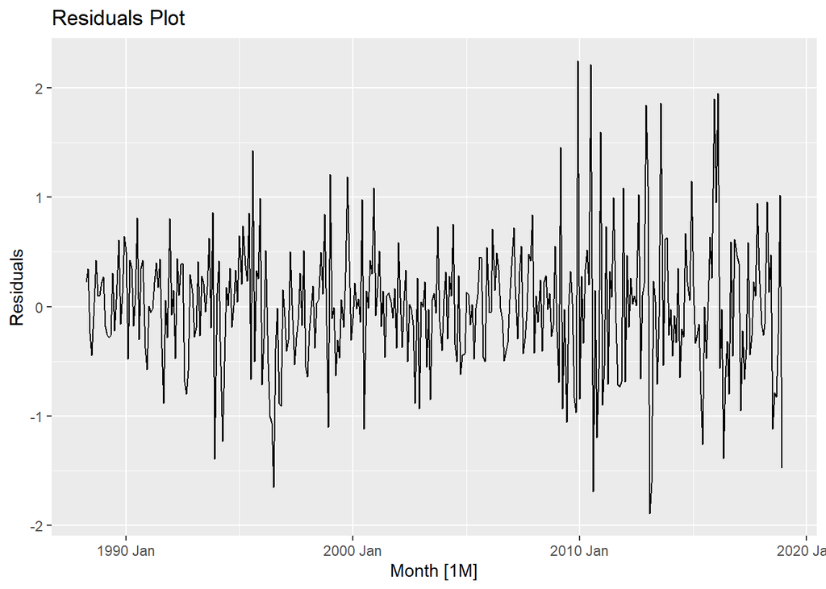

```r
##AAM (Best method based on slightly better RMSE value)
autoplot(residuals(aam))+
  labs(title = "Residuals Plot", y = "Residuals")
```

#### e) Now find the test set RMSE, while training the model to the end of 2010. Can you beat the seasonal naïve approach from Exercise 7 in Section 5.11?

Yes, by using and Additive trend and multiplicative seasonal accomodations the AAM type ETS model was able to obtain a smaller RMSE value than the SNAIVE model from Section 5.

```r
lim_2010 <- myseries |> filter(year(Month)<=2010)
## Taking better performing model

model_aam <- lim_2010 |> model(ETS(Turnover ~ error("A") + trend("A") + season("M")))
aam_fc <- model_aam |>  forecast(h = 12)
print(aam_fc)
```

```
## # A fable: 12 x 6 [1M]
## # Key:     State, Industry, .model [1]
##    State              Industry                .model    Month     Turnover .mean
##    <chr>              <chr>                   <chr>     <mth>       <dist> <dbl>
##  1 Northern Territory Clothing, footwear and… "ETS(… 2011 Jan sample[5000] 10.5
##  2 Northern Territory Clothing, footwear and… "ETS(… 2011 Feb sample[5000]  9.80
##  3 Northern Territory Clothing, footwear and… "ETS(… 2011 Mar sample[5000] 10.9
##  4 Northern Territory Clothing, footwear and… "ETS(… 2011 Apr sample[5000] 11.0
##  5 Northern Territory Clothing, footwear and… "ETS(… 2011 May sample[5000] 12.6
##  6 Northern Territory Clothing, footwear and… "ETS(… 2011 Jun sample[5000] 13.3
##  7 Northern Territory Clothing, footwear and… "ETS(… 2011 Jul sample[5000] 14.8
##  8 Northern Territory Clothing, footwear and… "ETS(… 2011 Aug sample[5000] 14.7
##  9 Northern Territory Clothing, footwear and… "ETS(… 2011 Sep sample[5000] 13.7
## 10 Northern Territory Clothing, footwear and… "ETS(… 2011 Oct sample[5000] 13.8
## 11 Northern Territory Clothing, footwear and… "ETS(… 2011 Nov sample[5000] 13.3
## 12 Northern Territory Clothing, footwear and… "ETS(… 2011 Dec sample[5000] 17.7
```

```r
snaive_model <- lim_2010 |> model(SNAIVE(Turnover))
snaive_fc <- snaive_model |>  forecast(h = 12)
print(snaive_fc)
```

```
## # A fable: 12 x 6 [1M]
## # Key:     State, Industry, .model [1]
##    State              Industry                                   .model    Month
##    <chr>              <chr>                                      <chr>     <mth>
##  1 Northern Territory Clothing, footwear and personal accessory… SNAIV… 2011 Jan
##  2 Northern Territory Clothing, footwear and personal accessory… SNAIV… 2011 Feb
##  3 Northern Territory Clothing, footwear and personal accessory… SNAIV… 2011 Mar
##  4 Northern Territory Clothing, footwear and personal accessory… SNAIV… 2011 Apr
##  5 Northern Territory Clothing, footwear and personal accessory… SNAIV… 2011 May
##  6 Northern Territory Clothing, footwear and personal accessory… SNAIV… 2011 Jun
##  7 Northern Territory Clothing, footwear and personal accessory… SNAIV… 2011 Jul
##  8 Northern Territory Clothing, footwear and personal accessory… SNAIV… 2011 Aug
##  9 Northern Territory Clothing, footwear and personal accessory… SNAIV… 2011 Sep
## 10 Northern Territory Clothing, footwear and personal accessory… SNAIV… 2011 Oct
## 11 Northern Territory Clothing, footwear and personal accessory… SNAIV… 2011 Nov
## 12 Northern Territory Clothing, footwear and personal accessory… SNAIV… 2011 Dec
## # ℹ 2 more variables: Turnover <dist>, .mean <dbl>
```

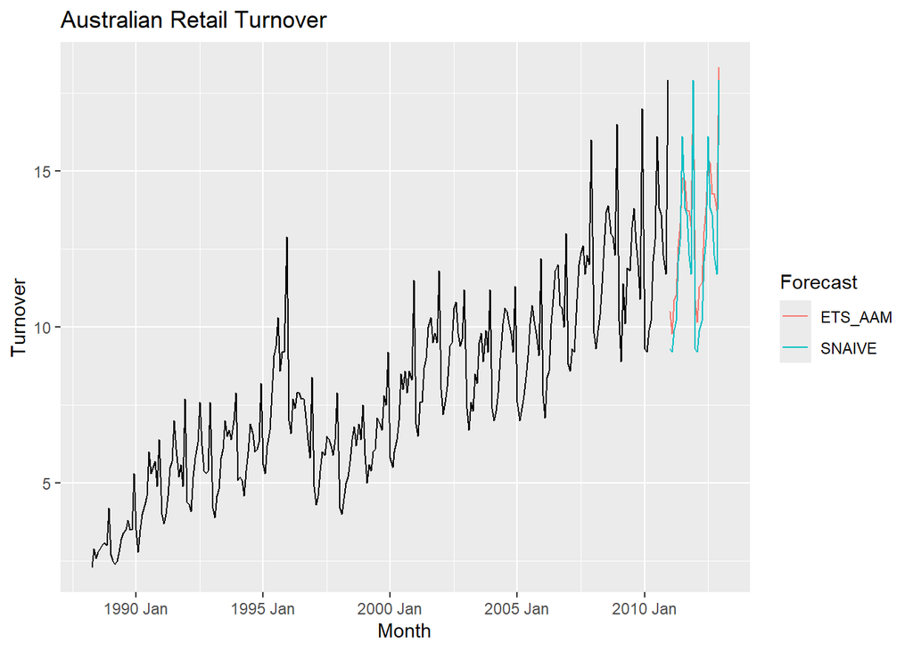

```r
#PLotting
lim_2010 |>
  model('ETS_AAM' = ETS(Turnover ~ error("A") + trend("A") + season("M")),
    'SNAIVE' = SNAIVE(Turnover)
    ) |>
  forecast(h = 24) |> # 2 years
  autoplot(lim_2010, level = NULL) +
  labs(title = "Australian Retail Turnover",
       y = "Turnover") +
  guides(colour = guide_legend(title = "Forecast"))
```

```r
## Looking at accuracy
print(accuracy(model_aam))#RMSE 0.5115981
```

```
## # A tibble: 1 × 12
##   State       Industry .model .type      ME  RMSE   MAE    MPE  MAPE  MASE RMSSE
##   <chr>       <chr>    <chr>  <chr>   <dbl> <dbl> <dbl>  <dbl> <dbl> <dbl> <dbl>
## 1 Northern T… Clothin… "ETS(… Trai… -0.0249 0.512 0.382 -0.661  5.28 0.418 0.422
## # ℹ 1 more variable: ACF1 <dbl>
```

```r
print(accuracy(snaive_model)) #1.213731 RMSE
```

```
## # A tibble: 1 × 12
##   State    Industry .model .type    ME  RMSE   MAE   MPE  MAPE  MASE RMSSE  ACF1
##   <chr>    <chr>    <chr>  <chr> <dbl> <dbl> <dbl> <dbl> <dbl> <dbl> <dbl> <dbl>
## 1 Norther… Clothin… SNAIV… Trai… 0.439  1.21 0.915  5.23  12.4     1     1 0.768
```

## 9) For the same retail data, try an STL decomposition applied to the Box-Cox transformed series, followed by ETS on the seasonally adjusted data. How does that compare with your best previous forecasts on the test set?

The RMSE for the season adjusted data with the same model on the limited training data Also used before is lower, meaning the error is lower so this model is better fitted.

```r
## BOX COX From Chapter 3
lambda <- lim_2010 |>  features(Turnover, features = guerrero) |>  pull(lambda_guerrero)
print(lambda)
```

```
## [1] 0.1971431
```

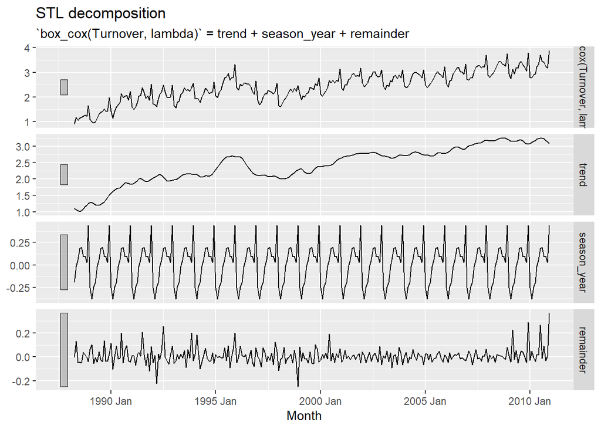

```r
stl_decomp <- lim_2010 |>
  model(
    STL(box_cox(Turnover, lambda) ~ trend(window = 7) +
                   season(window = "periodic"),
    robust = TRUE)) |>
  components()

## Decomp Plot
stl_decomp|>  autoplot()
```

```r
#Takign the season adjusted data out of the decomp
seasonally_adjusted_data <- stl_decomp |> select(season_adjust)

#MOdeling using AAM from before on adjusted data.
ets_decomp <-
  seasonally_adjusted_data |>
  model(ETS(season_adjust ~ error("A") + trend("A") + season("M")))


## COmparing to model before
accuracy(ets_decomp)#0.1036053 RMSE
```

```
## # A tibble: 1 × 10
##   .model             .type       ME  RMSE    MAE    MPE  MAPE  MASE RMSSE   ACF1
##   <chr>              <chr>    <dbl> <dbl>  <dbl>  <dbl> <dbl> <dbl> <dbl>  <dbl>
## 1 "ETS(season_adjus… Trai… -9.35e-4 0.104 0.0804 0.0103  3.70 0.425 0.413 0.0916
```

```r
accuracy(model_aam)#0.5115981 RMSE
```

```
## # A tibble: 1 × 12
##   State       Industry .model .type      ME  RMSE   MAE    MPE  MAPE  MASE RMSSE
##   <chr>       <chr>    <chr>  <chr>   <dbl> <dbl> <dbl>  <dbl> <dbl> <dbl> <dbl>
## 1 Northern T… Clothin… "ETS(… Trai… -0.0249 0.512 0.382 -0.661  5.28 0.418 0.422
## # ℹ 1 more variable: ACF1 <dbl>
```